# CutTagv4R179CvsWT

Yu Kuan Pan

2026-03-19

if the graph below doesn’t show as expect adjust the order here in sampleList @param sampleListW: List read all 3 alignment names ( wild type 1% replicate 1: KWA-62277_S34_L001, tgf replicate 1: KWA-62278_s35_L001, R179C replicate 1: KWA-62279_S36_L001) @param histListW: name listed for gene

```r
sampleListW <- c("wildType_Rep1", "wildType_Rep2", "wildType_Rep3",
                 "tgf_Rep1", "tgf_Rep2", "tgf_Rep3",
                 "R179C_Rep1", "R179C_Rep2", "R179C_Rep3")
histListW <- c("wildType", "tgf", "R179C")
```

```r
alignResultsW <- c()
files = list.files(path = "../alignment/samU/bowtie2_summary/", pattern = "_bowtie2.txt") # adjusted based on the file destination

files
```

```
## [1] "R179C_Rep1_KWA-62279_S36_L001_bowtie2.txt"
## [2] "R179C_Rep2_KWA-62282_S39_L001_bowtie2.txt"
## [3] "R179C_Rep3_KWA-62285_S42_L001_bowtie2.txt"
## [4] "tgf_Rep1_KWA-62278_S35_L001_bowtie2.txt"
## [5] "tgf_Rep2_KWA-62281_S38_L001_bowtie2.txt"
## [6] "tgf_Rep3_KWA-62284_S41_L001_bowtie2.txt"
## [7] "wildType_Rep1_KWA-62277_S34_L001_bowtie2.txt"
## [8] "wildType_Rep2_KWA-62280_S37_L001_bowtie2.txt"
## [9] "wildType_Rep3_KWA-62283_S40_L001_bowtie2.txt"
```

### Sequencing depth

```r
# Initialize an empty data frame before the loop
alignResults <- data.frame(Histone = character(),
                           Replicate = character(),
                           SequencingDepth = numeric(),
                           MappedFragNum_mm10 = numeric(),
                           AlignmentRate_mm10 = numeric(),
                           stringsAsFactors = FALSE)

# Loop through histone files
for(hist in files) {

  # adjusted based on the file destination
  alignRes <- read.table(paste0("../alignment/samU/bowtie2_summary/", hist), header = FALSE, fill = TRUE, stringsAsFactors = FALSE)

  # Extract alignment rate and remove the '%' symbol
  alignRate <- as.numeric(substr(alignRes$V1[6], 1, nchar(as.character(alignRes$V1[6])) - 1))

  # Ensure the numeric conversion does not fail
  mappedFragNum <- sum(as.numeric(alignRes$V1[4]), as.numeric(alignRes$V1[5]), na.rm = TRUE)

  # Extract histone and replicate information from filename
  histInfo <- unlist(strsplit(hist, "_"))

  # Append results
  alignResults <- rbind(alignResults, data.frame(
    Histone = histInfo[1],
    Replicate = histInfo[2],
    SequencingDepth = as.numeric(as.character(alignRes$V1[1])),
    MappedFragNum_mm10 = mappedFragNum,
    AlignmentRate_mm10 = alignRate
  ))
}

alignResults %>% mutate(AlignmentRate_mm10 = paste0(AlignmentRate_mm10, "%"))
```

```
##    Histone Replicate SequencingDepth MappedFragNum_mm10 AlignmentRate_mm10
## 1    R179C      Rep1        18180255           14067681             77.38%
## 2    R179C      Rep2        16745977           11753000             70.18%
## 3    R179C      Rep3        17712939           13087875             73.89%
## 4      tgf      Rep1        20568988           15648611             76.08%
## 5      tgf      Rep2        18486279           14863325              80.4%
## 6      tgf      Rep3        17483653           13110781             74.99%
## 7 wildType      Rep1        13074522           10227313             78.22%
## 8 wildType      Rep2        17331833           13842286             79.87%
## 9 wildType      Rep3        16232645           12898199             79.46%
```

```r
# Display the result
```

reorder the setting for visualization

```r
# Define the desired order for the Histone column
desired_order <- c("wildType", "tgf", "R179C")

# Convert Histone to a factor with the specified order
alignResults$Histone <- factor(alignResults$Histone, levels = desired_order)

# Reorder the dataframe based on the factor levels
alignResults <- alignResults[order(alignResults$Histone), ]

# Display the result
print(alignResults)
```

```
##    Histone Replicate SequencingDepth MappedFragNum_mm10 AlignmentRate_mm10
## 7 wildType      Rep1        13074522           10227313              78.22
## 8 wildType      Rep2        17331833           13842286              79.87
## 9 wildType      Rep3        16232645           12898199              79.46
## 4      tgf      Rep1        20568988           15648611              76.08
## 5      tgf      Rep2        18486279           14863325              80.40
## 6      tgf      Rep3        17483653           13110781              74.99
## 1    R179C      Rep1        18180255           14067681              77.38
## 2    R179C      Rep2        16745977           11753000              70.18
## 3    R179C      Rep3        17712939           13087875              73.89
```

Since we only need R179C vs WT for the poster, we can subset the data for better visualization

```r
alignResults <- subset(alignResults, Histone %in% c("wildType", "R179C"))
```

### Visualization for poster: Alignment Data

```r
# install.packages("DT", type = "source")
library(DT)

# Create a polished table
datatable(alignResults,
          rownames = FALSE,
          colnames = c("Condition", "Rep", "Seq Depth", "Mapped Frags", "Alignment %"),
          options = list(
              dom = 't',               # Table only (no search box)
              pageLength = 9,          # Show all rows
              columnDefs = list(list(className = 'dt-center', targets = "_all"))
          )) %>%
    # Add commas to big numbers
    formatCurrency(c('SequencingDepth', 'MappedFragNum_mm10'), currency = "", interval = 3, mark = ",", digits = 0) %>%
    # Add a heatmap effect to Alignment Rate to show quality
    formatStyle(
        'AlignmentRate_mm10',
        backgroundColor = styleInterval(c(75, 80), c('#DEEBF7', '#9ECAE1', '#4292C6')),
        fontWeight = 'bold'
)
```

| Condition | Rep | Seq Depth | Mapped Frags | Alignment % |
| --- | --- | --- | --- | --- |
| wildType | Rep1 | 13074522 | 10227313 | 78.22 |
| wildType | Rep2 | 17331833 | 13842286 | 79.87 |
| wildType | Rep3 | 16232645 | 12898199 | 79.46 |
| R179C | Rep1 | 18180255 | 14067681 | 77.38 |
| R179C | Rep2 | 16745977 | 11753000 | 70.18 |
| R179C | Rep3 | 17712939 | 13087875 | 73.89 |

##Visualizing the sequening depth and alignment results

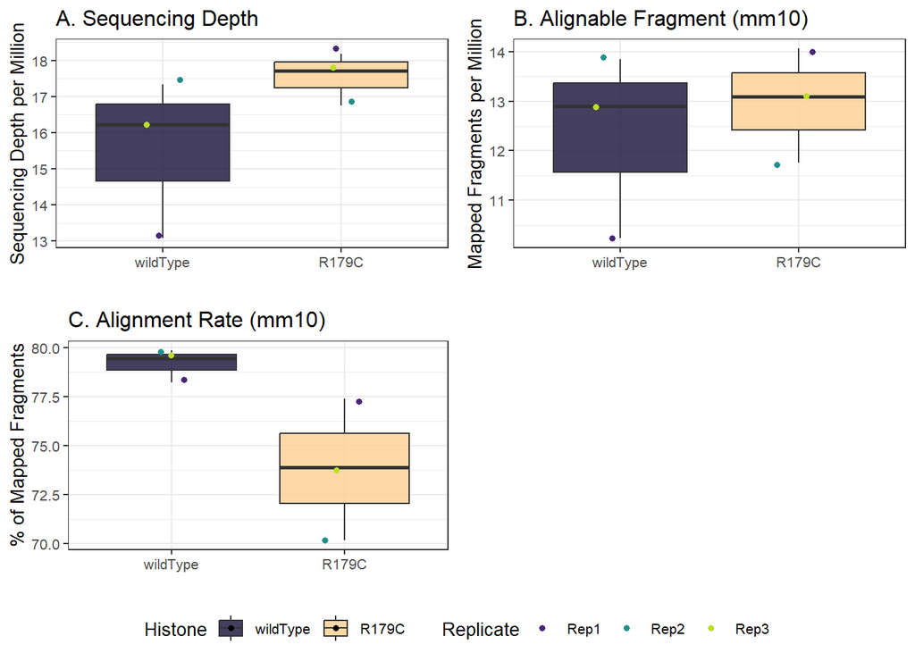

```r
fig3A = alignResults %>% ggplot(aes(x= Histone, y = SequencingDepth/1000000, fill = Histone))+geom_boxplot()+geom_jitter(aes(color= Replicate), position= position_jitter(0.15))+scale_fill_viridis(discrete = TRUE, begin = 0.1, end = 0.9, option = "magma", alpha = 0.8)+scale_color_viridis(discrete = T, begin = 0.1, end = 0.9)+theme_bw(base_size = 10)+ylab("Sequencing Depth per Million")+xlab("")+ggtitle("A. Sequencing Depth")

fig3B = alignResults %>% ggplot(aes(x= Histone, y= MappedFragNum_mm10/1000000, fill = Histone))+geom_boxplot()+geom_jitter(aes(color = Replicate), position = position_jitter(0.15)) + scale_fill_viridis(discrete = T, begin = 0.1, end = 0.9, option = "magma", alpha = 0.8) + scale_color_viridis(discrete = T, begin = 0.1, end = 0.9)+theme_bw(base_size = 10)+ylab("Mapped Fragments per Million")+xlab("")+ggtitle("B. Alignable Fragment (mm10)")

fig3C = alignResults %>% ggplot(aes(x = Histone, y = AlignmentRate_mm10, fill = Histone)) +
    geom_boxplot() +
    geom_jitter(aes(color = Replicate), position = position_jitter(0.15)) +
    scale_fill_viridis(discrete = TRUE, begin = 0.1, end = 0.9, option = "magma", alpha = 0.8) +
    scale_color_viridis(discrete = TRUE, begin = 0.1, end = 0.9) +
    theme_bw(base_size = 10) +
    ylab("% of Mapped Fragments") +
    xlab("") +
    ggtitle("C. Alignment Rate (mm10)")



ggarrange(fig3A, fig3B, fig3C, ncol = 2, nrow = 2, common.legend = T, legend = "bottom")
```

### Remove Duplicate

```r
DupResults <- c()
files = list.files(path = "../alignment/removeDuplicateU/picard_summary/", pattern = "_picard.rmDup.txt")

files
```

```
## [1] "R179C_Rep1_KWA-62279_S36_L001_picard.rmDup.txt"
## [2] "R179C_Rep2_KWA-62282_S39_L001_picard.rmDup.txt"
## [3] "R179C_Rep3_KWA-62285_S42_L001_picard.rmDup.txt"
## [4] "tgf_Rep1_KWA-62278_S35_L001_picard.rmDup.txt"
## [5] "tgf_Rep2_KWA-62281_S38_L001_picard.rmDup.txt"
## [6] "tgf_Rep3_KWA-62284_S41_L001_picard.rmDup.txt"
## [7] "wildType_Rep1_KWA-62277_S34_L001_picard.rmDup.txt"
## [8] "wildType_Rep2_KWA-62280_S37_L001_picard.rmDup.txt"
## [9] "wildType_Rep3_KWA-62283_S40_L001_picard.rmDup.txt"
```

add the duplication rate and estimated library size to the alignment summary table for better visualization

```r
histList<- c("wildType", "tgf", "R179C")
# Initialize an empty data frame before the loop
DupResults <- data.frame(Histone = character(),
                         Replicate = character(),
                         #SequencingDepth = numeric(),
                         MappedFragNum_mm10 = numeric(),
                         DuplicationRateRate_mm10 = numeric(),
                         EstimatedLibrarySize= numeric(),
                         stringsAsFactors = FALSE)

# Loop through histone files
for(hist in files) {

  dupRes <- read.table(paste0("../alignment/removeDuplicateU/picard_summary/", hist), header = TRUE, fill = TRUE, stringsAsFactors = FALSE)

  histInfo<- strsplit(hist, "_")[[1]]
  DupResults<- data.frame(Histone = histInfo[1], Replicate=  histInfo[2],
                          MappedFragNum_mm10 = dupRes$READ_PAIRS_EXAMINED[1] %>% as.character %>% as.numeric,
                          DuplicationRate_mm10 = dupRes$PERCENT_DUPLICATION[1] %>% as.character %>% as.numeric*100,
                          EstimatedLibrarySize = dupRes$ESTIMATED_LIBRARY_SIZE[1] %>% as.character %>% as.numeric) %>%
    mutate(UniqueFragNum = MappedFragNum_mm10 * (1-DuplicationRate_mm10/100)) %>% rbind(DupResults, .)
}

DupResults$Histone = factor(DupResults$Histone, levels = histList)
alignDupSummary = left_join(alignResults, DupResults, by = c("Histone", "Replicate", "MappedFragNum_mm10")) %>%
  mutate(DuplicationRate_mm10 = paste0(DuplicationRate_mm10, "%"))

DupResults
```

```
##    Histone Replicate MappedFragNum_mm10 DuplicationRate_mm10
## 1    R179C      Rep1           14067681              48.9861
## 2    R179C      Rep2           11753000              60.9342
## 3    R179C      Rep3           13087875              73.1425
## 4      tgf      Rep1           15648611              42.5651
## 5      tgf      Rep2           14863325              65.3093
## 6      tgf      Rep3           13110781              69.0091
## 7 wildType      Rep1           10227313              40.4967
## 8 wildType      Rep2           13842286              48.0780
## 9 wildType      Rep3           12898199              51.6146
##   EstimatedLibrarySize UniqueFragNum
## 1              9264554       7176473
## 2              5127890       4591403
## 3              3618130       3515076
## 4             12939403       8987764
## 5              5557388       5156191
## 6              4271053       4063149
## 7              9057952       6085589
## 8              9374404       7187192
## 9              7736467       6240845
```

```r
DupResults<- subset(DupResults, Histone %in% c("wildType", "R179C")) # since we only need the information of R179C vs WT for the poster, we can subset the data for better visualization
alignDupSummary
```

```
##    Histone Replicate SequencingDepth MappedFragNum_mm10 AlignmentRate_mm10
## 1 wildType      Rep1        13074522           10227313              78.22
## 2 wildType      Rep2        17331833           13842286              79.87
## 3 wildType      Rep3        16232645           12898199              79.46
## 4    R179C      Rep1        18180255           14067681              77.38
## 5    R179C      Rep2        16745977           11753000              70.18
## 6    R179C      Rep3        17712939           13087875              73.89
##   DuplicationRate_mm10 EstimatedLibrarySize UniqueFragNum
## 1             40.4967%              9057952       6085589
## 2              48.078%              9374404       7187192
## 3             51.6146%              7736467       6240845
## 4             48.9861%              9264554       7176473
## 5             60.9342%              5127890       4591403
## 6             73.1425%              3618130       3515076
```

```r
# Display the result
```

```r
# 1. Pre-process: Handle the specific column name 'DuplicationRateRate_mm10'
# We create hidden numeric columns (Dup_Num, Align_Num) to drive the colors
plot_data <- alignDupSummary %>%
  mutate(
    # Use the exact name from your dataframe to avoid 'object not found' error
    Dup_Num = as.numeric(gsub("%", "", DuplicationRate_mm10)),
    Align_Num = as.numeric(AlignmentRate_mm10)
  )

# 2. Create the polished interactive table for the poster
datatable(plot_data,
          rownames = FALSE,
          # Rename columns for the final display to look professional
          colnames = c("Condition", "Replicate", "Seq Depth", "Mapped Frags",
                       "Alignment %", "Duplication %", "Est. Lib Size", "Unique Frags",
                       "Dup_Hidden", "Align_Hidden"),
          options = list(
              dom = 't',                         # Table only (cleaner for posters)
              pageLength = 6,                    # Display all rows
              columnDefs = list(
                  list(visible = FALSE, targets = c(8, 9)), # Hide helper numeric columns
                  list(className = 'dt-center', targets = "_all")
              )
          )) %>%
    # Format integers with commas for high-quality scientific reporting
    formatCurrency(c('SequencingDepth', 'MappedFragNum_mm10', 'EstimatedLibrarySize', 'UniqueFragNum'),
                   currency = "", interval = 3, mark = ",", digits = 0) %>%
    # Apply Blue Heatmap to Alignment Rate
    formatStyle(
        'AlignmentRate_mm10',
        'Align_Num',
        backgroundColor = styleInterval(c(70, 75), c('#DEEBF7', '#9ECAE1', '#4292C6')),
        fontWeight = 'bold'
    ) %>%
    # Apply Green Heatmap to Duplication Rate
    formatStyle(
        'DuplicationRate_mm10',
        'Dup_Num',
        backgroundColor = styleInterval(c(50, 65), c('#F7FCF0', '#E0F3DB', '#A8DDB5'))
    )
```

| Condition | Replicate | Seq Depth | Mapped Frags | Alignment % | Duplication % | Est. Lib Size | Unique Frags | Dup_Hidden | Align_Hidden |
| --- | --- | --- | --- | --- | --- | --- | --- | --- | --- |
| wildType | Rep1 | 13074522 | 10227313 | 78.22 | 40.4967% | 9057952 | 6085588.736329 | 40.4967 | 78.22 |
| wildType | Rep2 | 17331833 | 13842286 | 79.87 | 48.078% | 9374404 | 7187191.73692 | 48.078 | 79.87 |
| wildType | Rep3 | 16232645 | 12898199 | 79.46 | 51.6146% | 7736467 | 6240845.178946001 | 51.6146 | 79.46 |
| R179C | Rep1 | 18180255 | 14067681 | 77.38 | 48.9861% | 9264554 | 7176472.717659 | 48.9861 | 77.38 |
| R179C | Rep2 | 16745977 | 11753000 | 70.18 | 60.9342% | 5127890 | 4591403.473999999 | 60.9342 | 70.18 |
| R179C | Rep3 | 17712939 | 13087875 | 73.89 | 73.1425% | 3618130 | 3515076.028125 | 73.1425 | 73.89 |

### remove duplicated plot

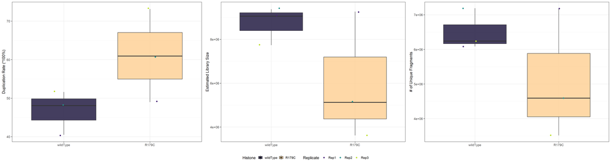

```r
fig4A = DupResults %>% ggplot(aes(x= Histone, y= DuplicationRate_mm10, fill= Histone)) +
  geom_boxplot()+
  geom_jitter(aes(color = Replicate), position = position_jitter(0.15))+
  scale_fill_viridis(discrete = TRUE, begin = 0.1, end = 0.9, option = "magma", alpha = 0.8)+
  scale_color_viridis(discrete = TRUE, begin = 0.1, end = 0.9)+
  theme_bw(base_size = 14)+
  ylab("Duplication Rate (*100%)")+
  xlab("")

fig4B = DupResults %>% ggplot(aes(x= Histone, y = EstimatedLibrarySize, fill= Histone)) +
  geom_boxplot()+
  geom_jitter(aes(color = Replicate), position = position_jitter(0.15))+
  scale_fill_viridis(discrete = TRUE, begin = 0.1, end = 0.9, option = "magma", alpha = 0.8)+
  scale_color_viridis(discrete = TRUE, begin = 0.1, end = 0.9)+
  theme_bw(base_size = 14)+
  ylab("Estimated Library Size")+
  xlab("")

fig4C = DupResults %>% ggplot(aes(x= Histone, y= UniqueFragNum, fill = Histone))+
  geom_boxplot()+
  geom_jitter(aes(color= Replicate), position = position_jitter(0.15))+
  scale_fill_viridis(discrete = TRUE, begin = 0.1, end = 0.9, option = "magma", alpha = 0.8)+
  scale_color_viridis(discrete = TRUE, begin = 0.1, end = 0.9)+
  theme_bw(base_size = 14)+
  ylab("# of Unique Fragments")+
  xlab("")

ggarrange(fig4A, fig4B, fig4C, ncol = 3, common.legend = T, legend = "bottom")
```

#### fraglen info

```r
FragResults <- c()
files = list.files(path = "../alignment/samU/fragmentLen/", pattern = "_fragmentLen.txt")

files
```

```
## [1] "R179C_Rep1_KWA-62279_S36_L001_fragmentLen.txt"
## [2] "R179C_Rep2_KWA-62282_S39_L001_fragmentLen.txt"
## [3] "R179C_Rep3_KWA-62285_S42_L001_fragmentLen.txt"
## [4] "tgf_Rep1_KWA-62278_S35_L001_fragmentLen.txt"
## [5] "tgf_Rep2_KWA-62281_S38_L001_fragmentLen.txt"
## [6] "tgf_Rep3_KWA-62284_S41_L001_fragmentLen.txt"
## [7] "wildType_Rep1_KWA-62277_S34_L001_fragmentLen.txt"
## [8] "wildType_Rep2_KWA-62280_S37_L001_fragmentLen.txt"
## [9] "wildType_Rep3_KWA-62283_S40_L001_fragmentLen.txt"
```

```r
fragLen <- NULL
for(hist in files){
  histInfo<- strsplit(hist, "_")[[1]]
  temp<- read.table(paste0("../alignment/samU/fragmentLen/", hist), header = F) %>%
    mutate(fragLen = V1 %>% as.numeric,
           fragCount = V2 %>% as.numeric,
           Weight= as.numeric(V2)/sum(as.numeric(V2)),
           Histone = histInfo[1],
           Replicate = histInfo[2],
           sampleIfo =
             paste0(histInfo[1], "_", histInfo[2]))
    fragLen <- bind_rows(fragLen, temp)
}

fragLen<- subset(fragLen, Histone %in% c("wildType", "R179C")) # since we only need the information of R179C vs WT for the poster, we can subset the data for better visualization
```

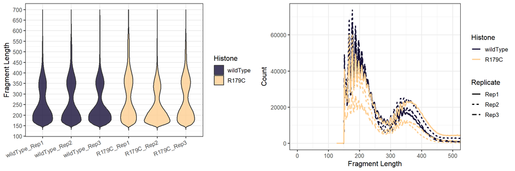

```r
fragLen <- NULL

for (hist in files) {
  histInfo <- strsplit(hist, "_")[[1]]
  histoneName <- histInfo[1]
  replicateName <- histInfo[2]

  temp <- read.table(paste0("../alignment/samU/fragmentLen/", hist), header = FALSE) %>%
    mutate(
      fragLen = as.numeric(V1),
      fragCount = as.numeric(V2),
      Weight = fragCount / sum(fragCount),
      Histone = histoneName,
      Replicate = replicateName,
      sampleInfo = paste0(histInfo[1], "_", histInfo[2])
    )
  temp<- subset(temp, Histone %in% c("wildType", "R179C")) # since we only need the information of R179C vs WT for the poster, we can subset the data for better visualization
  fragLen <- bind_rows(fragLen, temp)
}

# Convert to factors
fragLen$sampleInfo <- factor(fragLen$sampleInfo, levels = sampleListW)
fragLen$Histone <- factor(fragLen$Histone, levels = c("wildType", "R179C"))

fig5A <- fragLen %>%
  ggplot(aes(
    x = sampleInfo,
    y = fragLen,
    weight = Weight,
    fill = Histone
  )) +
  geom_violin(bw = 5) +
  scale_y_continuous(breaks = seq(0, 800, 50)) +
  scale_fill_viridis(
    discrete = TRUE,
    begin = 0.1, end = 0.9,
    option = "magma", alpha = 0.8
  ) +
  theme_bw(base_size = 12) +
  ggpubr::rotate_x_text(angle = 20) +
  ylab("Fragment Length") +
  xlab("")

# Line plot of fragment length distributions by sample
fig5B <- fragLen %>%
  filter(!is.na(fragLen), !is.na(fragCount)) %>%
  ggplot(aes(
    x = fragLen,
    y = fragCount,
    color = Histone,
    group = sampleInfo,
    linetype = Replicate
  )) +
  geom_line(linewidth = 1) +
  scale_color_viridis(
    discrete = TRUE,
    begin = 0.1, end = 0.9,
    option = "magma"
  ) +
  theme_bw(base_size = 12) +
  xlab("Fragment Length") +
  ylab("Count") +
  coord_cartesian(xlim = c(0, 500))

# Combine the two plots side by side
ggarrange(fig5A, fig5B, ncol = 2)
```

# Update part

the update part start from here with the new bam file and bed ## Assess Replicate reproducibility

```r
FragResults <- c()
files = list.files(path = "../alignment/bedWOEcoli/", pattern = "_bowtie2.fragmentsCount.bin500.bed")

files
```

```
##  [1] "KWA-62277_S34_L001_bowtie2.fragmentsCount.bin500.bed"
##  [2] "KWA-62278_S35_L001_bowtie2.fragmentsCount.bin500.bed"
##  [3] "KWA-62279_S36_L001_bowtie2.fragmentsCount.bin500.bed"
##  [4] "KWA-62280_S37_L001_bowtie2.fragmentsCount.bin500.bed"
##  [5] "KWA-62281_S38_L001_bowtie2.fragmentsCount.bin500.bed"
##  [6] "KWA-62282_S39_L001_bowtie2.fragmentsCount.bin500.bed"
##  [7] "KWA-62283_S40_L001_bowtie2.fragmentsCount.bin500.bed"
##  [8] "KWA-62284_S41_L001_bowtie2.fragmentsCount.bin500.bed"
##  [9] "KWA-62285_S42_L001_bowtie2.fragmentsCount.bin500.bed"
## [10] "R179C_Rep1_KWA-62279_S36_L001_bowtie2.fragmentsCount.bin500.bed"
## [11] "R179C_Rep2_KWA-62282_S39_L001_bowtie2.fragmentsCount.bin500.bed"
## [12] "R179C_Rep3_KWA-62285_S42_L001_bowtie2.fragmentsCount.bin500.bed"
## [13] "tgf_Rep1_KWA-62278_S35_L001_bowtie2.fragmentsCount.bin500.bed"
## [14] "tgf_Rep2_KWA-62281_S38_L001_bowtie2.fragmentsCount.bin500.bed"
## [15] "tgf_Rep3_KWA-62284_S41_L001_bowtie2.fragmentsCount.bin500.bed"
## [16] "wildType_Rep1_KWA-62277_S34_L001_bowtie2.fragmentsCount.bin500.bed"
## [17] "wildType_Rep2_KWA-62280_S37_L001_bowtie2.fragmentsCount.bin500.bed"
## [18] "wildType_Rep3_KWA-62283_S40_L001_bowtie2.fragmentsCount.bin500.bed"
```

```r
library(dplyr)
library(corrplot)

# Your file list (already loaded)
# Make sure the `files` vector is defined

# Initialize
fragCount <- NULL

for (file in files) {

  # Extract sample name (e.g., "R179C_Rep1") from the filename
  sample_name <- strsplit(file, "_KWA")[[1]][1]

  # Read fragment count file (3-column BED-like: chrom, bin, count)
  frag_tmp <- read.table(paste0("../alignment/bedWOEcoli/", file), header = FALSE)
  colnames(frag_tmp) <- c("chrom", "bin", sample_name)

  # Merge
  if (is.null(fragCount)) {
    fragCount <- frag_tmp
  } else {
    fragCount <- full_join(fragCount, frag_tmp, by = c("chrom", "bin"))
  }
}


# Define proper sample order by group
sample_order <- c(
  "R179C_Rep1", "R179C_Rep2", "R179C_Rep3",
  "wildType_Rep1", "wildType_Rep2", "wildType_Rep3"
)

# Check if all sample names were correctly extracted
if (!all(sample_order %in% colnames(fragCount))) {
  stop("Some expected sample names are missing. Please double-check filename parsing.")
}

# Select and reorder samples, log2 transform
frag_mat <- fragCount %>%
  select(all_of(sample_order)) %>%
  log2()

# Compute correlation matrix
cor_mat <- cor(frag_mat, use = "complete.obs")
```

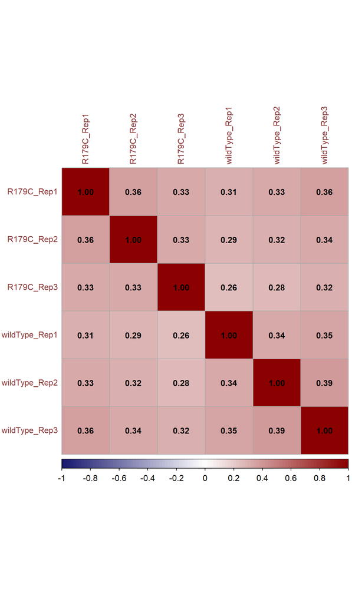

```r
# Plot
corrplot(cor_mat[sample_order, sample_order],
         method = "color",
         outline = TRUE,
         addgrid.col = "darkgray",
         order = "original",   # critical to preserve your group ordering
         addrect = 3,
         rect.col = "black", rect.lwd = 3,
         cl.pos = "b", tl.col = "indianred4", tl.cex = 1,
         cl.cex = 1, addCoef.col = "black",
         number.digits = 2, number.cex = 1,
         col = colorRampPalette(c("midnightblue", "white", "darkred"))(100))
```

```r
frag_mat[is.na(frag_mat)] <- 0
frag_mat_filtered <- frag_mat[apply(frag_mat, 1, function(x) var(x) > 0), ]
```

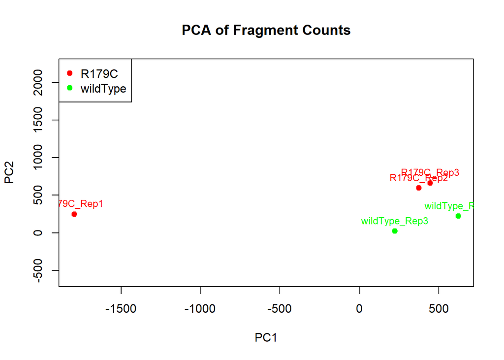

```r
# After computing PCA as before
pca <- prcomp(t(log2(frag_mat_filtered + 1)), scale. = TRUE)

# Assign group colors
group_colors <- rep(c("red", "green"), each = 3)

# Define sample names (same order as in frag_mat)
sample_labels <- colnames(frag_mat_filtered)

# Plot with labels
plot(pca$x[,1], pca$x[,2],
     col = group_colors,
     pch = 19, xlab = "PC1", ylab = "PC2", main = "PCA of Fragment Counts", ylim = c(-600, 2200))

# Add text labels to each point
text(pca$x[,1], pca$x[,2],
     labels = sample_labels,
     pos = 3, cex = 0.8, col = group_colors)

# Add legend
legend("topleft",
       legend = c("R179C", "wildType"),
       col = c("red", "green"),
       pch = 19)
```

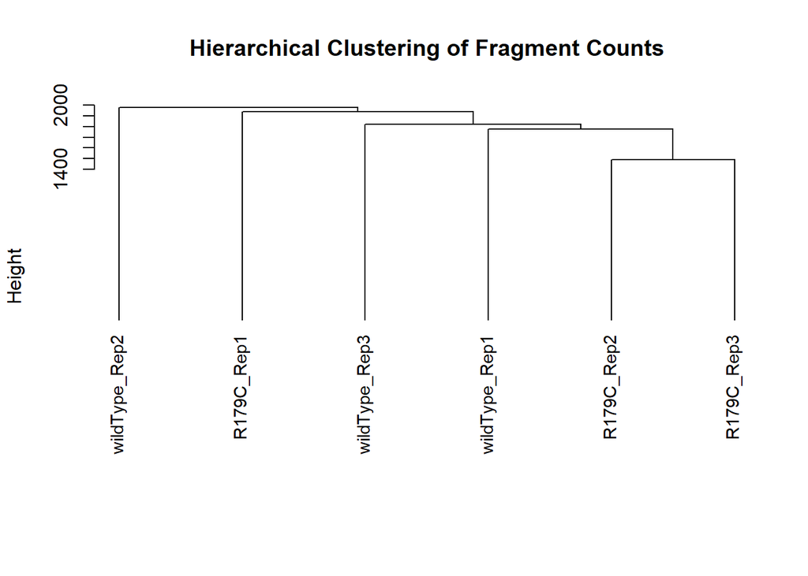

```r
# Assuming frag_mat is already log2-transformed and ordered
frag_mat[is.na(frag_mat)] <- 0

# Filter rows with variance > 0 (as in your PCA)
frag_mat_filtered <- frag_mat[apply(frag_mat, 1, function(x) var(x) > 0), ]

# Transpose to cluster **samples**, not bins
frag_mat_t <- t(frag_mat_filtered)

# Compute distance matrix
dist_mat <- dist(frag_mat_t, method = "euclidean")

# Hierarchical clustering
hc <- hclust(dist_mat, method = "complete")  # or "average", "ward.D2", etc.

# Plot dendrogram
plot(hc,
     main = "Hierarchical Clustering of Fragment Counts",
     xlab = "",
     sub = "",
     cex = 0.9,
     hang = -1)
```

# PeakCalling

instead of using SEACR or Scaling Factor for normalization we utilized goPeak to call peaks and then use the called peaks to do the downstream analysis.

## GoPeak Result (slide 50 step 20)

this study apply two different argument to calculated peaks the first filter is slide 50, which means the window size for calculating the local background is 50bp, and the second filter is step 20, which means the step size for sliding the window is 20bp. The combination of these two parameters allows us to identify peaks with a certain level of resolution and sensitivity, while also controlling for local background noise in our ChIP-seq data.

```r
histL = c("R179C", "tgfB", "wildType")
repL = paste0("Rep", 1:3)
peakSummary = data.frame()

for(hist in histL){
  # Temporary list to store GRanges for this condition
  temp_rep_list <- list()

  # Step 1: Read all available replicates first
  for(rep in repL){
    pattern_string <- paste0(hist, "_", rep, ".*_peaks")

    target_file <- list.files(
      path = "../cutTagRes/cutAndTag/goPeakRes_Step50_slide20/",
      pattern = pattern_string,
      full.names = TRUE)

    target_file <- target_file[!grepl("Identifier", target_file)]

    if(length(target_file) > 0){
      peakInfo = read.table(target_file[1], header = FALSE)
      message("Successfully read: ", basename(target_file[1]))

      peak_gr = GRanges(seqnames = peakInfo$V1,
                        ranges = IRanges(start = peakInfo$V2, end = peakInfo$V3))

      # Store the GRanges in our list named by the Replicate
      temp_rep_list[[rep]] <- peak_gr
    } else {
      warning("Could not find file for ", hist, " ", rep)
    }
  }

  # Step 2: Calculate the Common Peak set (Intersection of all found replicates)
  if(length(temp_rep_list) >= 2){
    # Start with the first replicate
    common_gr = temp_rep_list[[1]]

    # Intersect with every subsequent replicate found
    for(i in 2:length(temp_rep_list)){
      hits = findOverlaps(common_gr, temp_rep_list[[i]])
      common_gr = common_gr[unique(queryHits(hits))]
    }

    # This is your final consensus count (e.g., 604)
    final_consensus_count = length(common_gr)

    # Step 3: Create rows for the table using the final consensus count
    for(rep_name in names(temp_rep_list)){
      temp_row = data.frame(
        Histone = hist,
        Replicate = rep_name,
        peakN = length(temp_rep_list[[rep_name]]), # Total in this file (e.g., 1973)
        peakReprodNum = final_consensus_count      # Always the common count (e.g., 604)
      )
      peakSummary = rbind(peakSummary, temp_row)
    }

    # Optional: Save the consensus BED file for your Heatmap
    # rtracklayer::export(common_gr, paste0(hist, "_consensus_peaks.bed"))

  } else {
    message("Not enough replicates to calculate overlap for ", hist)
  }
}
```

```
## Successfully read: R179C_Rep1_s36_peaks.bed
```

```
## Successfully read: R179C_Rep2_s39_peaks.bed
```

```
## Successfully read: R179C_Rep3_s42_peaks.bed
```

```
## Successfully read: tgfB_Rep1_s35_peaks.bed
```

```
## Successfully read: tgfB_Rep2_s38_peaks.bed
```

```
## Successfully read: tgfB_Rep3_s41_peaks.bed
```

```
## Successfully read: wildType_Rep1_s34_peaks.bed
```

```
## Successfully read: wildType_Rep2_s37_peaks.bed
```

```
## Successfully read: wildType_Rep3_s40_peaks.bed
```

```r
# Step 4: Final Calculation
peakReprod = peakSummary %>%
  mutate(peakReprodRate = (peakReprodNum / peakN) * 100)

print(peakReprod)
```

```
##    Histone Replicate peakN peakReprodNum peakReprodRate
## 1    R179C      Rep1  1973           485       24.58186
## 2    R179C      Rep2  1210           485       40.08264
## 3    R179C      Rep3   893           485       54.31131
## 4     tgfB      Rep1  1811           529       29.21038
## 5     tgfB      Rep2  1558           529       33.95379
## 6     tgfB      Rep3  1014           529       52.16963
## 7 wildType      Rep1   781           531       67.98976
## 8 wildType      Rep2  1607           531       33.04294
## 9 wildType      Rep3  1993           531       26.64325
```

since the study only focusing on comparing the different between R179C and wildtype, we can subset the data for better visualization

```r
peakReprodSub<- subset(peakReprod, Histone %in% c("R179C", "wildType"))
peakReprodSub
```

```
##    Histone Replicate peakN peakReprodNum peakReprodRate
## 1    R179C      Rep1  1973           485       24.58186
## 2    R179C      Rep2  1210           485       40.08264
## 3    R179C      Rep3   893           485       54.31131
## 7 wildType      Rep1   781           531       67.98976
## 8 wildType      Rep2  1607           531       33.04294
## 9 wildType      Rep3  1993           531       26.64325
```

```r
library(DT)
library(dplyr)
# 1. Pre-process: No string conversion needed since these are already integers/doubles
# We use peakReprodRate directly for the heatmap effect
plot_peak_data <- peakReprodSub

# 2. Create the polished Peak Reproduction table
datatable(plot_peak_data,
          rownames = FALSE,
          # Rename headers to be professional for the poster
          colnames = c("Condition", "Replicate", "Total Peaks", "Reproduced Peaks", "Reproduction %"),
          options = list(
              dom = 't',                         # Clean layout: table only
              pageLength = 6,                    # Show all rows
              columnDefs = list(
                  list(className = 'dt-center', targets = "_all")
              )
          )) %>%
    # Format peak counts with commas
    formatCurrency(c('peakN', 'peakReprodNum'),
                   currency = "", interval = 3, mark = ",", digits = 0) %>%
    # Format the Rate to 2 decimal places
    formatRound('peakReprodRate', 2) %>%
    # Apply a Green Heatmap to Reproduction Rate (Higher = More Consistent)
    formatStyle(
        'peakReprodRate',
        backgroundColor = styleInterval(c(30, 50), c('#F7FCF0', '#E0F3DB', '#A8DDB5')),
        fontWeight = 'bold'
    )
```

| Condition | Replicate | Total Peaks | Reproduced Peaks | Reproduction % |
| --- | --- | --- | --- | --- |
| R179C | Rep1 | 1973 | 485 | 24.5818550430816 |
| R179C | Rep2 | 1210 | 485 | 40.08264462809917 |
| R179C | Rep3 | 893 | 485 | 54.31131019036955 |
| wildType | Rep1 | 781 | 531 | 67.98975672215109 |
| wildType | Rep2 | 1607 | 531 | 33.04293714996889 |
| wildType | Rep3 | 1993 | 531 | 26.6432513798294 |

## master peak (general 3 replicate sample )

the purpose is to get the master peak list for the heatmap, which is the union of all peaks across all samples. This will allow us to have a comprehensive set of peaks to analyze and visualize in the heatmap, ensuring that we capture all relevant regions of interest from our ChIP-seq data.

```r
mPeak = GRanges()
## overlap with bam file to get count
for(hist in histL){
  for(rep in repL){
    pattern_string <- paste0(hist, "_", rep, ".*_peaks")

    target_file <- list.files(
      path = "../cutTagRes/cutAndTag/goPeakRes_Step50_slide20/",
      pattern = pattern_string,
      full.names = TRUE)

    target_file <- target_file[!grepl("Identifier", target_file)]

    if(length(target_file) > 0){
      peakInfo = read.table(target_file[1], header = FALSE)
      message("Successfully read: ", basename(target_file[1]))

      mPeak = GRanges(seqnames = peakInfo$V1,
                        ranges = IRanges(start = peakInfo$V2, end = peakInfo$V3), strand = "*") %>% append (mPeak, .)
    } else {
      warning("Could not find file for ", hist, " ", rep)
    }


  }
}
```

```
## Successfully read: R179C_Rep1_s36_peaks.bed
```

```
## Successfully read: R179C_Rep2_s39_peaks.bed
```

```
## Successfully read: R179C_Rep3_s42_peaks.bed
```

```
## Successfully read: tgfB_Rep1_s35_peaks.bed
```

```
## Successfully read: tgfB_Rep2_s38_peaks.bed
```

```
## Successfully read: tgfB_Rep3_s41_peaks.bed
```

```
## Successfully read: wildType_Rep1_s34_peaks.bed
```

```
## Successfully read: wildType_Rep2_s37_peaks.bed
```

```
## Successfully read: wildType_Rep3_s40_peaks.bed
```

```r
masterPeak = reduce(mPeak)
```

## Get the fragment counts for each peak in the master peak list

```r
#library(DESeq2)

# Initialize the matrix
countMat = matrix(NA, length(masterPeak),
                  length(histL) * length(repL))
directory = "../alignment/bamWOEcoli/noEcoli/"
# Get the fragment counts for each peak in the master peak list.
i = 1
for(hist in histL){
  for(rep in repL){

    # 1. Create a pattern that looks for BOTH the condition and the replicate
    # Example: "R179C_Rep1" followed by anything, ending in our BAM suffix
    file_pattern <- paste0(hist, "_", rep, ".*_bowtie2\\.mapped\\.noEcoli\\.bam$")

    # 2. Search for the file in your directory
    target_file <- list.files(path = directory, pattern = file_pattern, full.names = TRUE)

    # 3. Safety check: Make sure we found exactly one file
    if(length(target_file) > 0){
      message("Successfully matched: ", basename(target_file[1]))

      # Use the matched filename for getCounts
      fragment_counts <- getCounts(target_file[1], masterPeak, paired = TRUE, by_rg = FALSE, format = "bam")
      countMat[, i] = counts(fragment_counts)[,1]

    } else {
      warning("ERROR: Could not find a file matching pattern: ", file_pattern)
    }

    i = i + 1
  }
}
```

```
## Successfully matched: R179C_Rep1_KWA-62279_S36_L001_bowtie2.mapped.noEcoli.bam
```

```
## Reading in file: ../alignment/bamWOEcoli/noEcoli/R179C_Rep1_KWA-62279_S36_L001_bowtie2.mapped.noEcoli.bam
```

```
## Successfully matched: R179C_Rep2_KWA-62282_S39_L001_bowtie2.mapped.noEcoli.bam
```

```
## Reading in file: ../alignment/bamWOEcoli/noEcoli/R179C_Rep2_KWA-62282_S39_L001_bowtie2.mapped.noEcoli.bam
```

```
## Successfully matched: R179C_Rep3_KWA-62285_S42_L001_bowtie2.mapped.noEcoli.bam
```

```
## Reading in file: ../alignment/bamWOEcoli/noEcoli/R179C_Rep3_KWA-62285_S42_L001_bowtie2.mapped.noEcoli.bam
```

```
## Successfully matched: tgfB_Rep1_KWA-62278_S35_L001_bowtie2.mapped.noEcoli.bam
```

```
## Reading in file: ../alignment/bamWOEcoli/noEcoli/tgfB_Rep1_KWA-62278_S35_L001_bowtie2.mapped.noEcoli.bam
```

```
## Successfully matched: tgfB_Rep2_KWA-62281_S38_L001_bowtie2.mapped.noEcoli.bam
```

```
## Reading in file: ../alignment/bamWOEcoli/noEcoli/tgfB_Rep2_KWA-62281_S38_L001_bowtie2.mapped.noEcoli.bam
```

```
## Successfully matched: tgfB_Rep3_KWA-62284_S41_L001_bowtie2.mapped.noEcoli.bam
```

```
## Reading in file: ../alignment/bamWOEcoli/noEcoli/tgfB_Rep3_KWA-62284_S41_L001_bowtie2.mapped.noEcoli.bam
```

```
## Successfully matched: wildType_Rep1_KWA-62277_S34_L001_bowtie2.mapped.noEcoli.bam
```

```
## Reading in file: ../alignment/bamWOEcoli/noEcoli/wildType_Rep1_KWA-62277_S34_L001_bowtie2.mapped.noEcoli.bam
```

```
## Successfully matched: wildType_Rep2_KWA-62280_S37_L001_bowtie2.mapped.noEcoli.bam
```

```
## Reading in file: ../alignment/bamWOEcoli/noEcoli/wildType_Rep2_KWA-62280_S37_L001_bowtie2.mapped.noEcoli.bam
```

```
## Successfully matched: wildType_Rep3_KWA-62283_S40_L001_bowtie2.mapped.noEcoli.bam
```

```
## Reading in file: ../alignment/bamWOEcoli/noEcoli/wildType_Rep3_KWA-62283_S40_L001_bowtie2.mapped.noEcoli.bam
```

```r
colnames(countMat) = paste(rep(histL, each = 3), rep(repL, 3),
                           sep = "_")
```

run the code below is any of the code below run into undefine function issue

```r
peak_ids <- paste(seqnames(masterPeak), start(masterPeak), end(masterPeak), sep="_")
rownames(countMat) <- peak_ids
```

## Sequencing depth normalization and differential enriched peaks detection

```r
selectR = which(rowSums((countMat> 0)) >= 5) # remove low count genes
dataS = countMat[selectR,]

condition <- factor(rep(histL, each = length(repL)))

dds<- DESeqDataSetFromMatrix(countData = dataS,
                              colData = DataFrame(condition),
                              design = ~ condition)
DDS<- DESeq(dds)
normDDS<- counts(DDS, normalized=TRUE) ## normalization with respect to the sequencing depth
colnames(normDDS) = paste0(colnames(normDDS), "_norm")
res = results(DDS, independentFiltering = FALSE,
              altHypothesis = "greaterAbs")
countMatDiff = cbind(dataS, normDDS, res)
#head(countMatDiff)
```

## compare differntial enriched peaks between different conditions

```r
res_R179C<- results(DDS, contrast = c("condition", "R179C", "wildType"), independentFiltering = FALSE, altHypothesis = "greaterAbs")
```

combining raw count, normalized count and the result of differential enriched peaks detection for each comparison with R179C mutate based

```r
countMatDiff_R179C = cbind(dataS, normDDS, res_R179C)
```

take the significant peaks with log2FoldChange > 1 and padj < 0.05 for each comparison

```r
sig_R179C <- res_R179C[which(res_R179C$padj < 0.05 & res_R179C$log2FoldChange > 1), ] # only one peaks is found even with arugement padj< 0.05
```

```r
coords<- as.data.frame(masterPeak[selectR])
results_table<- cbind(coords[, c("seqnames", "start",
                                 "end")],
                      countMatDiff_R179C)
repressive_candidate<- results_table[which(results_table$padj < 0.05 & results_table$log2FoldChange > 1), ]
rownames(repressive_candidate)
```

```
## [1] "chr17_11327860_11329230"
```

since we only find one peak with standard filtering method the study will focus on the strict unique found in unique peak information

## Match unique/strick unique peak

## Peak Filter (R179C)

R179C unique peak match with the result table, the function will extract the peak information and the count information for the unique peak in R179C condition amount 3 replicate, the unique peak is defined as those peak that select amount one type of replicate only, like 3 replicate

```r
R179C_unique<- extract_target_peak(res_table = results_table,
                             bed_path = "../cutTagRes/cutAndTag/goPeakRes_Step50_slide20/UniqueR179C.bed",
                             master_gr = masterPeak,
                             select_index = selectR)
```

```
## Sucessfully matched 485 out of 485
```

R179 Strict Unique peak match with the result table, the function will extract the peak information and the count information for the strict unique peak in R179C condition amount 3 replicate, the strict unique peak is defined as those peak that select amount one type of replicate only, like 3 replicate and also not found in other condition

```r
R179C_strict_unique<- extract_target_peak(res_table = results_table,
                             bed_path = "../cutTagRes/cutAndTag/goPeakRes_Step50_slide20/only_R179C_strict.bed",
                             master_gr = masterPeak,
                             select_index = selectR)
```

```
## Sucessfully matched 119 out of 119
```

## inverse Match Execution

```r
#BiocManager::install(c("ChIPseeker",
#                       "TxDb.Mmusculus.UCSC.mm10.knownGene",
#                       "org.Mm.eg.db",
#                       "clusterProfiler"))
library(ChIPseeker)
library(TxDb.Mmusculus.UCSC.mm10.knownGene)
library(org.Mm.eg.db)
```

R179C unique peak summary and annotation

```r
R179C_Peak_Summary<- chipSeekFunc(peakInfo = R179C_unique)
```

```
## >> preparing features information...      2026-03-19 4:31:17 PM
## >> identifying nearest features...        2026-03-19 4:31:17 PM
## >> calculating distance from peak to TSS...   2026-03-19 4:31:17 PM
## >> assigning genomic annotation...        2026-03-19 4:31:17 PM
## >> adding gene annotation...          2026-03-19 4:31:27 PM
```

```
## >> assigning chromosome lengths           2026-03-19 4:31:28 PM
## >> done...                    2026-03-19 4:31:28 PM
```

```r
dim(R179C_Peak_Summary)
```

```
## [1] 499  18
```

```r
R179C_strict_Peak_Summary<- chipSeekFunc(peakInfo = R179C_strict_unique)
```

```
## >> preparing features information...      2026-03-19 4:31:28 PM
## >> identifying nearest features...        2026-03-19 4:31:28 PM
## >> calculating distance from peak to TSS...   2026-03-19 4:31:28 PM
## >> assigning genomic annotation...        2026-03-19 4:31:28 PM
## >> adding gene annotation...          2026-03-19 4:31:29 PM
```

```
## >> assigning chromosome lengths           2026-03-19 4:31:29 PM
## >> done...                    2026-03-19 4:31:30 PM
```

```r
dim(R179C_strict_Peak_Summary)
```

```
## [1] 120  18
```

## GO Enrichment Analysis

R179C unique peak GO enrichment analysis

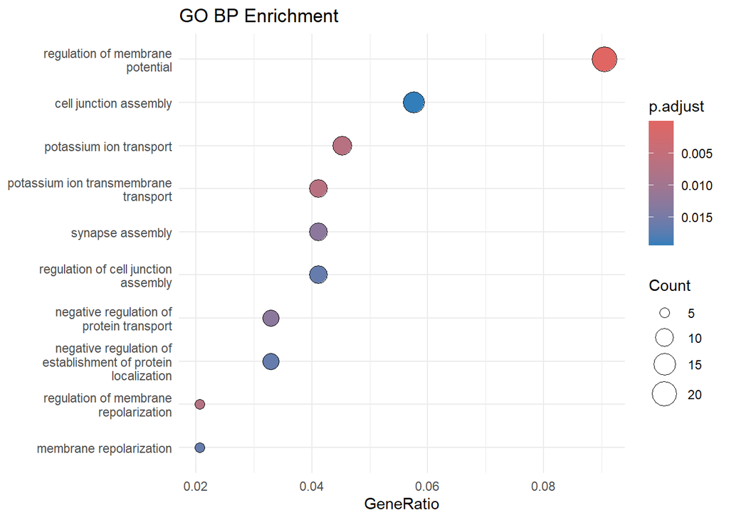

```
##                    ID
## GO:0042391 GO:0042391
## GO:0006813 GO:0006813
## GO:0071805 GO:0071805
## GO:0060306 GO:0060306
## GO:0051224 GO:0051224
## GO:0007416 GO:0007416
## GO:0086009 GO:0086009
## GO:1901888 GO:1901888
## GO:1904950 GO:1904950
## GO:0034329 GO:0034329
## GO:0051588 GO:0051588
## GO:1901890 GO:1901890
## GO:0050709 GO:0050709
## GO:0009953 GO:0009953
## GO:0071679 GO:0071679
## GO:0030534 GO:0030534
## GO:0051963 GO:0051963
## GO:0043266 GO:0043266
## GO:1902259 GO:1902259
## GO:0046928 GO:0046928
## GO:0051932 GO:0051932
## GO:0007411 GO:0007411
## GO:0097485 GO:0097485
## GO:0021695 GO:0021695
## GO:0001508 GO:0001508
## GO:0050805 GO:0050805
## GO:0060231 GO:0060231
##                                                             Description
## GO:0042391                             regulation of membrane potential
## GO:0006813                                      potassium ion transport
## GO:0071805                        potassium ion transmembrane transport
## GO:0060306                        regulation of membrane repolarization
## GO:0051224                     negative regulation of protein transport
## GO:0007416                                             synapse assembly
## GO:0086009                                      membrane repolarization
## GO:1901888                         regulation of cell junction assembly
## GO:1904950 negative regulation of establishment of protein localization
## GO:0034329                                       cell junction assembly
## GO:0051588                     regulation of neurotransmitter transport
```

[output cut: 113 more lines]

```
## GO:0050709     6
## GO:0009953     6
## GO:0071679     3
## GO:0030534     8
## GO:0051963     7
## GO:0043266     6
## GO:1902259     3
## GO:0046928     6
## GO:0051932     5
## GO:0007411     9
## GO:0097485     9
## GO:0021695     5
## GO:0001508     7
## GO:0050805     5
## GO:0060231     3
```

```r
GOPathFunc(annotated_df = R179C_Peak_Summary,
           pvalueCutoff = 0.05,
           method = "BP",
           DB = org.Mm.eg.db)
```

R179C strict unique peak GO enrichment analysis

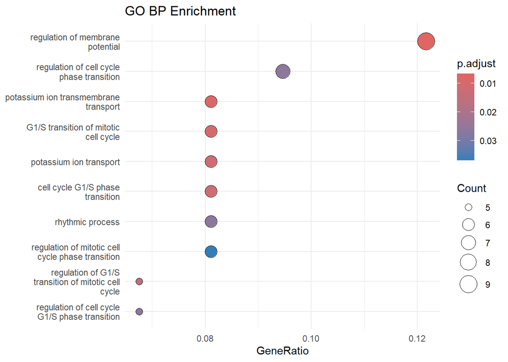

```
##                    ID                                         Description
## GO:0042391 GO:0042391                    regulation of membrane potential
## GO:0071805 GO:0071805               potassium ion transmembrane transport
## GO:0000082 GO:0000082               G1/S transition of mitotic cell cycle
## GO:0006813 GO:0006813                             potassium ion transport
## GO:0044843 GO:0044843                    cell cycle G1/S phase transition
## GO:2000045 GO:2000045 regulation of G1/S transition of mitotic cell cycle
## GO:1902806 GO:1902806      regulation of cell cycle G1/S phase transition
## GO:1901987 GO:1901987           regulation of cell cycle phase transition
## GO:0048511 GO:0048511                                    rhythmic process
## GO:1901990 GO:1901990   regulation of mitotic cell cycle phase transition
##            GeneRatio   BgRatio RichFactor FoldEnrichment   zScore       pvalue
## GO:0042391      9/74 495/28905 0.01818182       7.101966 6.937480 4.854923e-06
## GO:0071805      6/74 198/28905 0.03030303      11.836609 7.751702 1.204466e-05
## GO:0000082      6/74 219/28905 0.02739726      10.701592 7.301213 2.129703e-05
## GO:0006813      6/74 238/28905 0.02521008       9.847263 6.943386 3.395652e-05
## GO:0044843      6/74 247/28905 0.02429150       9.488456 6.787647 4.176297e-05
## GO:2000045      5/74 169/28905 0.02958580      11.556453 6.972896 7.487498e-05
## GO:1902806      5/74 195/28905 0.02564103      10.015593 6.399705 1.466193e-04
## GO:1901987      7/74 453/28905 0.01545254       6.035887 5.473103 1.614814e-04
## GO:0048511      6/74 320/28905 0.01875000       7.323902 5.763098 1.729273e-04
## GO:1901990      6/74 347/28905 0.01729107       6.754031 5.463086 2.672932e-04
##               p.adjust      qvalue
## GO:0042391 0.006714358 0.005616379
## GO:0071805 0.008328885 0.006966887
## GO:0000082 0.009817933 0.008212435
## GO:0006813 0.011551637 0.009662632
## GO:0044843 0.011551637 0.009662632
## GO:2000045 0.017258684 0.014436423
## GO:1902806 0.026573155 0.022227726
## GO:1901987 0.026573155 0.022227726
## GO:0048511 0.026573155 0.022227726
## GO:1901990 0.036966647 0.030921600
##                                                               geneID Count
## GO:0042391 Oprm1/Cacnb4/Kcnh8/Akap7/Cntnap2/Piezo2/Kcna4/Kcnj6/Kcna5     9
## GO:0071805                       Kcnh8/Dpp10/Akap7/Kcna4/Kcnj6/Kcna5     6
## GO:0000082                         Cacnb4/Ezh2/Rdx/Cdk6/Kcna5/Arid1b     6
## GO:0006813                       Kcnh8/Dpp10/Akap7/Kcna4/Kcnj6/Kcna5     6
## GO:0044843                         Cacnb4/Ezh2/Rdx/Cdk6/Kcna5/Arid1b     6
## GO:2000045                              Cacnb4/Ezh2/Rdx/Kcna5/Arid1b     5
## GO:1902806                              Cacnb4/Ezh2/Rdx/Kcna5/Arid1b     5
## GO:1901987                   Prox1/Cacnb4/Ezh2/Rdx/Cdk6/Kcna5/Arid1b     7
## GO:0048511                Prox1/Fshb/Ezh2/Cntnap2/Opn5/2610005L07Rik     6
## GO:1901990                         Cacnb4/Ezh2/Rdx/Cdk6/Kcna5/Arid1b     6
```

```r
GOPathFunc(annotated_df = R179C_strict_Peak_Summary,
           pvalueCutoff = 0.05,
           method = "BP",
           DB = org.Mm.eg.db)
```

Since we can’t really see the pattern between chip seq and bulk RNA seq, we will focus on keeping promoter gene for the analysis and see how it preformed in the differential expression result in bulk RNA

R179C

```r
R179C_Promoter_Summary<- R179C_Peak_Summary %>% filter(grepl("Promoter", annotation))
dim(R179C_Promoter_Summary)
```

```
## [1] 57 18
```

```r
head(R179C_Promoter_Summary$SYMBOL, 10)
```

```
##  [1] "Cep112" "Dop1b"  "Sfi1"   "Sfi1"   "Sfi1"   "Sfi1"   "Sfi1"   "Sfi1"
##  [9] "Tekt4"  "Thada"
```

```r
R179C_Strict_Promoter_Summary<- R179C_strict_Peak_Summary %>% filter(grepl("Promoter", annotation))
dim(R179C_Strict_Promoter_Summary)
```

```
## [1]  9 18
```

```r
head(R179C_Strict_Promoter_Summary$SYMBOL, 10)
```

```
## [1] "Sfi1"     "Tekt4"    "Thada"    "Slc45a1"  "Clvs1"    "Duxf4"    "Speer4e1"
## [8] "Gm21190"  "Rn45s"
```

## bulk RNA DEG match

#### R179C evaluation

first we need to check if the result we found in chip seq match the differential expression results from bulk RNA seq

```r
# Load the bulk RNA-seq DEGs
R179CBulk <- read.csv("./sig_R179C_vs_WT.csv" , header = TRUE)
colnames(R179CBulk)[1] <- "Gene"
colnames(R179CBulk)
```

```
## [1] "Gene"           "baseMean"       "log2FoldChange" "lfcSE"
## [5] "stat"           "pvalue"         "padj"
```

check if the promoter gene match with DEG results

```r
intersect_R179C <- intersect(R179C_Promoter_Summary$SYMBOL, R179CBulk$Gene)
intersect_R179C
```

```
## [1] "Dnah8"  "Prune2"
```

```r
R179CBulk[R179CBulk$Gene %in% intersect_R179C, ]
```

```
##        Gene  baseMean log2FoldChange     lfcSE      stat       pvalue
## 1019 Prune2 623.34992      -1.537194 0.3206113 -4.794574 1.630211e-06
## 1408  Dnah8  10.80501      -3.189912 0.7564181 -4.217129 2.474329e-05
##              padj
## 1019 3.125948e-05
## 1408 3.326133e-04
```

```r
# since R179C label 2 as promotor with arguement -5kb - 1kb write csv to export those information as well
write.csv(R179CBulk[R179CBulk$Gene %in% intersect_R179C, ], "./R179C_Bulk_Promoter_5kb_1kb.csv", row.names = FALSE)
```

check how the bulkRNA result with +- 50 kb

```r
# Define the columns you want to keep
PeakListInfo <- c("seqnames", "start", "end", "width", "annotation", "distanceToTSS", "SYMBOL")

# Filter rows for the 37 genes AND filter for the columns in PeakListInfo
R179C_Filtered_Summary <- R179C_Peak_Summary[R179C_Peak_Summary$SYMBOL %in% intersect_R179C, PeakListInfo]

R179C_Filtered_Summary[abs(R179C_Filtered_Summary$distanceToTSS) < 50000, ]
```

```
##     seqnames    start      end width       annotation distanceToTSS SYMBOL
## 136    chr17 30797900 30798990  1091 Promoter (1-2kb)         -1387  Dnah8
## 152    chr19 17138840 17139390   551 Promoter (<=1kb)           101 Prune2
```

```r
R179CBulk[R179CBulk$Gene %in% R179C_Filtered_Summary[abs(R179C_Filtered_Summary$distanceToTSS) < 50000, "SYMBOL"], ]
```

```
##        Gene  baseMean log2FoldChange     lfcSE      stat       pvalue
## 1019 Prune2 623.34992      -1.537194 0.3206113 -4.794574 1.630211e-06
## 1408  Dnah8  10.80501      -3.189912 0.7564181 -4.217129 2.474329e-05
##              padj
## 1019 3.125948e-05
## 1408 3.326133e-04
```

## summarized necessary file

```r
unique(R179C_Promoter_Summary$SYMBOL)
```

```
##  [1] "Cep112"    "Dop1b"     "Sfi1"      "Tekt4"     "Thada"     "Marchf8"
##  [7] "Gm9758"    "Dnah8"     "Trpm8"     "Prune2"    "Slc45a1"   "Rapgef1"
## [13] "Plcb4"     "Clvs1"     "Spink8"    "Tmem125"   "Ndfip2"    "Lepr"
## [19] "Adgrf2"    "Phf21a"    "Speer4c2"  "Speer4d"   "Ulbp3"     "Speer4e2"
## [25] "Spata31e2" "Potefam3a" "Duxf4"     "Dux"       "Mroh2a"    "Sox5os3"
## [31] "Speer4e1"  "Gm17019"   "Potefam3b" "Potefam3e" "Mir101c"   "Gm21190"
## [37] "Gm26504"   "Pisd-ps1"  "Rn45s"
```

```r
length(unique(R179C_Promoter_Summary$SYMBOL))
```

```
## [1] 39
```

```r
write.csv(R179C_Promoter_Summary, "./R179C_Promoter_5kb_1kb_peak_Summary.csv", row.names = FALSE)
```

## Check if the study focused gene match with the peak found in R179C

```r
FocusGene<- c("Acta2", "Cnn1", "Tagln", "Myh11", "Tspan2", "Itga8", "Smtn",
              "Dhx32os", "Myocd", "Mrtfa", "Lmod1")
R179C_Peak_Summary[R179C_Peak_Summary$SYMBOL %in% FocusGene, ]
```

```
##  [1] ENSEMBL       seqnames      start         end           width
##  [6] strand        annotation    geneChr       geneStart     geneEnd
## [11] geneLength    geneStrand    geneId        transcriptId  distanceToTSS
## [16] SYMBOL        GENENAME      ENTREZID
## <0 rows> (or 0-length row.names)
```

#### Gopeak result (slide 25 step 10 pval 0.05)

the whole data is under the directory goPeakRes_Step25_slide10 –pval 0.05

```r
histL = c("R179C", "tgfB", "wildType")
repL = paste0("Rep", 1:3)
peakSummary = data.frame()

for(hist in histL){
  # Temporary list to store GRanges for this condition
  temp_rep_list <- list()

  # Step 1: Read all available replicates first
  for(rep in repL){
    pattern_string <- paste0(hist, "_", rep, ".*_peaks")

    target_file <- list.files(
      path = "../cutTagRes/cutAndTag/goPeakRes_Step25_slide10/",
      pattern = pattern_string,
      full.names = TRUE)

    target_file <- target_file[!grepl("Identifier", target_file)]

    if(length(target_file) > 0){
      peakInfo = read.table(target_file[1], header = FALSE)
      message("Successfully read: ", basename(target_file[1]))

      peak_gr = GRanges(seqnames = peakInfo$V1,
                        ranges = IRanges(start = peakInfo$V2, end = peakInfo$V3))

      # Store the GRanges in our list named by the Replicate
      temp_rep_list[[rep]] <- peak_gr
    } else {
      warning("Could not find file for ", hist, " ", rep)
    }
  }

  # Step 2: Calculate the Common Peak set (Intersection of all found replicates)
  if(length(temp_rep_list) >= 2){
    # Start with the first replicate
    common_gr = temp_rep_list[[1]]

    # Intersect with every subsequent replicate found
    for(i in 2:length(temp_rep_list)){
      hits = findOverlaps(common_gr, temp_rep_list[[i]])
      common_gr = common_gr[unique(queryHits(hits))]
    }

    # This is your final consensus count (e.g., 604)
    final_consensus_count = length(common_gr)

    # Step 3: Create rows for the table using the final consensus count
    for(rep_name in names(temp_rep_list)){
      temp_row = data.frame(
        Histone = hist,
        Replicate = rep_name,
        peakN = length(temp_rep_list[[rep_name]]), # Total in this file (e.g., 1973)
        peakReprodNum = final_consensus_count      # Always the common count (e.g., 604)
      )
      peakSummary = rbind(peakSummary, temp_row)
    }

    # Optional: Save the consensus BED file for your Heatmap
    # rtracklayer::export(common_gr, paste0(hist, "_consensus_peaks.bed"))

  } else {
    message("Not enough replicates to calculate overlap for ", hist)
  }
}
```

```
## Successfully read: R179C_Rep1_s36_peaks.bed
```

```
## Successfully read: R179C_Rep2_s39_peaks.bed
```

```
## Successfully read: R179C_Rep3_s42_peaks.bed
```

```
## Successfully read: tgfB_Rep1_s35_step30_slide10_peaks.bed
```

```
## Successfully read: tgfB_Rep2_s38_step30_slide10_peaks.bed
```

```
## Successfully read: tgfB_Rep3_s41_step30_slide10_peaks.bed
```

```
## Successfully read: wildType_Rep1_s34_peaks.bed
```

```
## Successfully read: wildType_Rep2_s37_peaks.bed
```

```
## Successfully read: wildType_Rep3_s40_peaks.bed
```

```r
# Step 4: Final Calculation
peakReprod = peakSummary %>%
  mutate(peakReprodRate = (peakReprodNum / peakN) * 100)

print(peakReprod)
```

```
##    Histone Replicate peakN peakReprodNum peakReprodRate
## 1    R179C      Rep1   807           305       37.79430
## 2    R179C      Rep2   596           305       51.17450
## 3    R179C      Rep3   457           305       66.73961
## 4     tgfB      Rep1   793           336       42.37074
## 5     tgfB      Rep2   767           336       43.80704
## 6     tgfB      Rep3   559           336       60.10733
## 7 wildType      Rep1   350           264       75.42857
## 8 wildType      Rep2   706           264       37.39377
## 9 wildType      Rep3   882           264       29.93197
```

```r
library(DT)
library(dplyr)
peakReprodSub<- subset(peakReprod, Histone %in% c("R179C", "wildType"))
# 1. Pre-process: No string conversion needed since these are already integers/doubles
# We use peakReprodRate directly for the heatmap effect
plot_peak_data <- peakReprodSub

# 2. Create the polished Peak Reproduction table
datatable(plot_peak_data,
          rownames = FALSE,
          # Rename headers to be professional for the poster
          colnames = c("Condition", "Replicate", "Total Peaks", "Reproduced Peaks", "Reproduction %"),
          options = list(
              dom = 't',                         # Clean layout: table only
              pageLength = 6,                    # Show all rows
              columnDefs = list(
                  list(className = 'dt-center', targets = "_all")
              )
          )) %>%
    # Format peak counts with commas
    formatCurrency(c('peakN', 'peakReprodNum'),
                   currency = "", interval = 3, mark = ",", digits = 0) %>%
    # Format the Rate to 2 decimal places
    formatRound('peakReprodRate', 2) %>%
    # Apply a Green Heatmap to Reproduction Rate (Higher = More Consistent)
    formatStyle(
        'peakReprodRate',
        backgroundColor = styleInterval(c(30, 50), c('#F7FCF0', '#E0F3DB', '#A8DDB5')),
        fontWeight = 'bold'
    )
```

| Condition | Replicate | Total Peaks | Reproduced Peaks | Reproduction % |
| --- | --- | --- | --- | --- |
| R179C | Rep1 | 807 | 305 | 37.79429987608427 |
| R179C | Rep2 | 596 | 305 | 51.1744966442953 |
| R179C | Rep3 | 457 | 305 | 66.73960612691467 |
| wildType | Rep1 | 350 | 264 | 75.42857142857143 |
| wildType | Rep2 | 706 | 264 | 37.39376770538244 |
| wildType | Rep3 | 882 | 264 | 29.93197278911565 |

## master peak (general 3 replicate sample )

the purpose is to get the master peak list for the heatmap, which is the union of all peaks across all samples. This will allow us to have a comprehensive set of peaks to analyze and visualize in the heatmap, ensuring that we capture all relevant regions of interest from our ChIP-seq data.

```r
mPeak = GRanges()
## overlap with bam file to get count
for(hist in histL){
  for(rep in repL){
    pattern_string <- paste0(hist, "_", rep, ".*_peaks")

    target_file <- list.files(
      path = "../cutTagRes/cutAndTag/goPeakRes_Step25_slide10/",
      pattern = pattern_string,
      full.names = TRUE)

    target_file <- target_file[!grepl("Identifier", target_file)]

    if(length(target_file) > 0){
      peakInfo = read.table(target_file[1], header = FALSE)
      message("Successfully read: ", basename(target_file[1]))

      mPeak = GRanges(seqnames = peakInfo$V1,
                        ranges = IRanges(start = peakInfo$V2, end = peakInfo$V3), strand = "*") %>% append (mPeak, .)
    } else {
      warning("Could not find file for ", hist, " ", rep)
    }


  }
}
```

```
## Successfully read: R179C_Rep1_s36_peaks.bed
```

```
## Successfully read: R179C_Rep2_s39_peaks.bed
```

```
## Successfully read: R179C_Rep3_s42_peaks.bed
```

```
## Successfully read: tgfB_Rep1_s35_step30_slide10_peaks.bed
```

```
## Successfully read: tgfB_Rep2_s38_step30_slide10_peaks.bed
```

```
## Successfully read: tgfB_Rep3_s41_step30_slide10_peaks.bed
```

```
## Successfully read: wildType_Rep1_s34_peaks.bed
```

```
## Successfully read: wildType_Rep2_s37_peaks.bed
```

```
## Successfully read: wildType_Rep3_s40_peaks.bed
```

```r
masterPeak = reduce(mPeak)
```

## Get the fragment counts for each peak in the master peak list

```r
#library(DESeq2)

# Initialize the matrix
countMat = matrix(NA, length(masterPeak),
                  length(histL) * length(repL))

# Get the fragment counts for each peak in the master peak list.
i = 1
for(hist in histL){
  for(rep in repL){

    # 1. Create a pattern that looks for BOTH the condition and the replicate
    # Example: "R179C_Rep1" followed by anything, ending in our BAM suffix
    file_pattern <- paste0(hist, "_", rep, ".*_bowtie2\\.mapped\\.noEcoli\\.bam$")

    # 2. Search for the file in your directory
    target_file <- list.files(path = "../alignment/bamWOEcoli/noEcoli/", pattern = file_pattern, full.names = TRUE)

    # 3. Safety check: Make sure we found exactly one file
    if(length(target_file) > 0){
      message("Successfully matched: ", basename(target_file[1]))

      # Use the matched filename for getCounts
      fragment_counts <- getCounts(target_file[1], masterPeak, paired = TRUE, by_rg = FALSE, format = "bam")
      countMat[, i] = counts(fragment_counts)[,1]

    } else {
      warning("ERROR: Could not find a file matching pattern: ", file_pattern)
    }

    i = i + 1
  }
}
```

```
## Successfully matched: R179C_Rep1_KWA-62279_S36_L001_bowtie2.mapped.noEcoli.bam
```

```
## Reading in file: ../alignment/bamWOEcoli/noEcoli/R179C_Rep1_KWA-62279_S36_L001_bowtie2.mapped.noEcoli.bam
```

```
## Successfully matched: R179C_Rep2_KWA-62282_S39_L001_bowtie2.mapped.noEcoli.bam
```

```
## Reading in file: ../alignment/bamWOEcoli/noEcoli/R179C_Rep2_KWA-62282_S39_L001_bowtie2.mapped.noEcoli.bam
```

```
## Successfully matched: R179C_Rep3_KWA-62285_S42_L001_bowtie2.mapped.noEcoli.bam
```

```
## Reading in file: ../alignment/bamWOEcoli/noEcoli/R179C_Rep3_KWA-62285_S42_L001_bowtie2.mapped.noEcoli.bam
```

```
## Successfully matched: tgfB_Rep1_KWA-62278_S35_L001_bowtie2.mapped.noEcoli.bam
```

```
## Reading in file: ../alignment/bamWOEcoli/noEcoli/tgfB_Rep1_KWA-62278_S35_L001_bowtie2.mapped.noEcoli.bam
```

```
## Successfully matched: tgfB_Rep2_KWA-62281_S38_L001_bowtie2.mapped.noEcoli.bam
```

```
## Reading in file: ../alignment/bamWOEcoli/noEcoli/tgfB_Rep2_KWA-62281_S38_L001_bowtie2.mapped.noEcoli.bam
```

```
## Successfully matched: tgfB_Rep3_KWA-62284_S41_L001_bowtie2.mapped.noEcoli.bam
```

```
## Reading in file: ../alignment/bamWOEcoli/noEcoli/tgfB_Rep3_KWA-62284_S41_L001_bowtie2.mapped.noEcoli.bam
```

```
## Successfully matched: wildType_Rep1_KWA-62277_S34_L001_bowtie2.mapped.noEcoli.bam
```

```
## Reading in file: ../alignment/bamWOEcoli/noEcoli/wildType_Rep1_KWA-62277_S34_L001_bowtie2.mapped.noEcoli.bam
```

```
## Successfully matched: wildType_Rep2_KWA-62280_S37_L001_bowtie2.mapped.noEcoli.bam
```

```
## Reading in file: ../alignment/bamWOEcoli/noEcoli/wildType_Rep2_KWA-62280_S37_L001_bowtie2.mapped.noEcoli.bam
```

```
## Successfully matched: wildType_Rep3_KWA-62283_S40_L001_bowtie2.mapped.noEcoli.bam
```

```
## Reading in file: ../alignment/bamWOEcoli/noEcoli/wildType_Rep3_KWA-62283_S40_L001_bowtie2.mapped.noEcoli.bam
```

```r
colnames(countMat) = paste(rep(histL, each = 3), rep(repL, 3),
                           sep = "_")
```

run the code below is any of the code below run into undefine function issue

```r
peak_ids <- paste(seqnames(masterPeak), start(masterPeak), end(masterPeak), sep="_")
rownames(countMat) <- peak_ids
```

## Sequencing depth normalization and differential enriched peaks detection

```r
selectR = which(rowSums((countMat> 0)) >= 5) # remove low count genes
dataS = countMat[selectR,]

condition <- factor(rep(histL, each = length(repL)))

dds<- DESeqDataSetFromMatrix(countData = dataS,
                              colData = DataFrame(condition),
                              design = ~ condition)
DDS<- DESeq(dds)
normDDS<- counts(DDS, normalized=TRUE) ## normalization with respect to the sequencing depth
colnames(normDDS) = paste0(colnames(normDDS), "_norm")
res = results(DDS, independentFiltering = FALSE,
              altHypothesis = "greaterAbs")
countMatDiff = cbind(dataS, normDDS, res)
#head(countMatDiff)
```

## compare differntial enriched peaks between different conditions

```r
res_R179C<- results(DDS, contrast = c("condition", "R179C", "wildType"), independentFiltering = FALSE, altHypothesis = "greaterAbs")
```

take the significant peaks with log2FoldChange > 1 and padj < 0.05 for each comparison

```r
sig_R179C <- res_R179C[which(res_R179C$padj < 0.05 & res_R179C$log2FoldChange > 1), ]
```

combining raw count, normalized count and the result of differential enriched peaks detection for each comparison with R179C mutate based

```r
countMatDiff_R179C = cbind(dataS, normDDS, res_R179C)

coords<- as.data.frame(masterPeak[selectR])
results_table_R179C<- cbind(coords[, c("seqnames", "start",
                                 "end")],
                      countMatDiff_R179C)
repressive_candidate_R179C<- results_table_R179C[which(results_table_R179C$padj < 0.05 & results_table_R179C$log2FoldChange > 1), ]
rownames(repressive_candidate_R179C)
```

```
## [1] "chr17_11327880_11329215"
```

from the result we got from repressive_candidate_R179C the only peak shown as significant is the peak located at: chr17: 11327880: 11329215 ## Match unique/2 out of 3 unique peak

## Peak Filter (R179C)

R179C unique peak match with the result table, the function will extract the peak information and the count information for the unique peak in R179C condition amount 3 replicate, the unique peak is defined as those peak that select amount one type of replicate only, like 3 replicate

```r
R179C_unique<- extract_target_peak(res_table = results_table_R179C,
                             bed_path = "../cutTagRes/cutAndTag/goPeakRes_Step25_slide10/unique_R179C.bed",
                             master_gr = masterPeak,
                             select_index = selectR)
```

```
## Sucessfully matched 305 out of 305
```

```r
R179C_2out3<- extract_target_peak(res_table = results_table_R179C,
                             bed_path = "../cutTagRes/cutAndTag/goPeakRes_Step25_slide10/R179C_2out3.bed",
                             master_gr = masterPeak,
                             select_index = selectR)
```

```
## Sucessfully matched 1023 out of 1023
```

## inverse Match Execution

```r
#BiocManager::install(c("ChIPseeker",
#                       "TxDb.Mmusculus.UCSC.mm10.knownGene",
#                       "org.Mm.eg.db",
#                       "clusterProfiler"))
library(ChIPseeker)
library(TxDb.Mmusculus.UCSC.mm10.knownGene)
library(org.Mm.eg.db)
```

R179C unique peak summary and annotation

```r
R179C_Peak_Summary<- chipSeekFunc(peakInfo = R179C_unique)
```

```
## >> preparing features information...      2026-03-19 4:36:45 PM
## >> identifying nearest features...        2026-03-19 4:36:45 PM
## >> calculating distance from peak to TSS...   2026-03-19 4:36:45 PM
## >> assigning genomic annotation...        2026-03-19 4:36:45 PM
## >> adding gene annotation...          2026-03-19 4:36:47 PM
```

```
## >> assigning chromosome lengths           2026-03-19 4:36:47 PM
## >> done...                    2026-03-19 4:36:47 PM
```

```r
dim(R179C_Peak_Summary)
```

```
## [1] 312  18
```

```r
R179C_2out3_Peak_Summary<- chipSeekFunc(peakInfo = R179C_2out3)
```

```
## >> preparing features information...      2026-03-19 4:36:47 PM
## >> identifying nearest features...        2026-03-19 4:36:47 PM
## >> calculating distance from peak to TSS...   2026-03-19 4:36:48 PM
## >> assigning genomic annotation...        2026-03-19 4:36:48 PM
## >> adding gene annotation...          2026-03-19 4:36:49 PM
```

```
## >> assigning chromosome lengths           2026-03-19 4:36:50 PM
## >> done...                    2026-03-19 4:36:50 PM
```

```r
dim(R179C_2out3_Peak_Summary )
```

```
## [1] 1051   18
```

## promotor check -5kb to +1kb

#### R179C unique peak/2out3 promotor check

```r
R179C_Promoter_Summary<- R179C_Peak_Summary %>% filter(grepl("Promoter", annotation))
dim(R179C_Promoter_Summary)
```

```
## [1] 41 18
```

```r
head(R179C_Promoter_Summary$SYMBOL, 10)
```

```
##  [1] "Cep112"  "Dop1b"   "Sfi1"    "Sfi1"    "Sfi1"    "Tekt4"   "Thada"
##  [8] "Marchf8" "Gm9758"  "Prune2"
```

```r
R179C_2out3_Promoter_Summary<- R179C_2out3_Peak_Summary %>% filter(grepl("Promoter", annotation))
dim(R179C_2out3_Promoter_Summary)
```

```
## [1] 138  18
```

```r
head(R179C_2out3_Promoter_Summary$SYMBOL, 10)
```

```
##  [1] "Cep112" "Cep112" "Cep112" "Dop1b"  "Dop1b"  "Sfi1"   "Sfi1"   "Sfi1"
##  [9] "Sfi1"   "Sfi1"
```

## bulk RNA DEG match

#### R179C evaluation (-5kb to +1kb)

first we need to check if the result we found in chip seq match the differential expression results from bulk RNA seq

```r
# Load the bulk RNA-seq DEGs
R179CBulk <- read.csv("./sig_R179C_vs_WT.csv" , header = TRUE)
colnames(R179CBulk)[1] <- "Gene"
colnames(R179CBulk)
```

```
## [1] "Gene"           "baseMean"       "log2FoldChange" "lfcSE"
## [5] "stat"           "pvalue"         "padj"
```

check if the promoter gene match with DEG results (R179C unique)

```r
intersect_R179C <- intersect(R179C_Promoter_Summary$SYMBOL, R179CBulk$Gene)
intersect_R179C
```

```
## [1] "Prune2"
```

```r
R179CBulk[R179CBulk$Gene %in% intersect_R179C, ]
```

```
##        Gene baseMean log2FoldChange     lfcSE      stat       pvalue
## 1019 Prune2 623.3499      -1.537194 0.3206113 -4.794574 1.630211e-06
##              padj
## 1019 3.125948e-05
```

check if the promoter gene match with DEG results (R179C 2out3)

```r
intersect_R179C_2out3 <- intersect(R179C_2out3_Promoter_Summary$SYMBOL, R179CBulk$Gene)
intersect_R179C_2out3
```

```
## [1] "Dnah8"   "Prune2"  "Tmem267"
```

```r
R179CBulk[R179CBulk$Gene %in% intersect_R179C_2out3, ]
```

```
##         Gene  baseMean log2FoldChange     lfcSE      stat       pvalue
## 768  Tmem267  42.58967      -1.047463 0.3296685 -3.177321 1.486422e-03
## 1019  Prune2 623.34992      -1.537194 0.3206113 -4.794574 1.630211e-06
## 1408   Dnah8  10.80501      -3.189912 0.7564181 -4.217129 2.474329e-05
##              padj
## 768  1.077261e-02
## 1019 3.125948e-05
## 1408 3.326133e-04
```